# Zapier Interview Project

Kristin Haldeman

July 19, 2017

## Introduction:

This is the interview project of Kristin Haldeman for the position of Data Engineer/Analyst at Zapier. Throughout each step, I try to thoroughly detail my thoughts throughout all steps. I chose an RMD format so that you could see code, results, and explanations continuously. I take on a more professional tone instep 3, leaving out extraneous details and focusing on presenting the findings.

## Step 1: Ingest data

This was a step that I performed outside of R and will summarize. I downloaded and installed PostgreSQL and set up a database server on my local machine. Using pgAdmin4, I connected to the database, and then copied the table into my local database by making a backup of the Zapier table. I loaded it into my local database by then running the sql insert commands from the backup.

However, I got stuck on the last part - I could never quite get the sql insert commands to load from the backup. And in the interest of both ‘default to action’ and the fact that I simply ran out of time due to me leaving for vacation for the next two weeks. I therefore exported the data via pgAdmin4 from the Zapier database into a csv file, and went from there. The InsertZapier.sql file inside InsertZapier.zip contains the sql commands I had backed up from the Zapier database

## Step 2: ETL

First open a Postgresql connection and load data, if I had a table with data in it in my local database. Since I don’t, I’ll leave this here for how it would have worked, and do a simple read.csv instead

```r
### create a connection
pw <- "haldeman921"

### loads the PostgreSQL driver
drv <- dbDriver("PostgreSQL")
# creates a connection to the postgres database
con <- dbConnect(drv, dbname = "postgres",
                 host = "localhost", port = 5432,
                 user = "openpg", password = pw)
rm(pw) # removes the password

### load the data
tasks <- sqldf("select * from postgres.tasks_used")
```

```r
tasks = read.csv("tasks_used.csv")
```

At first I just did some basic summarization and data checking. Sanity checks are always in order before starting an analysis of the data, and gives me a good background for proceeding with the analysis, debugging, and answering questions that might come up later by those looking at the analysis. These calculations can be found in the Exploration.R file. Are the number of unique users (299522) more than the number of unique accounts (299419)? Yup, multiple users for a few accounts, this makes sense. Whats the time frame of the data? January 1 - June 4 2017, so we have about 5 months of data to work with. A summary of tasks used per day shows us that we only have entries if at least one task was performed on a day - no data means no tasks performed -  
something I assumed by looking at the data, but I am glad I checked on. A histogram of tasks/day and log(tasks/day) gives us an expected exponential decline in this variable.

Next I start transforming this data into what I will use for visualizations

```r
#### create daily time series table for use in analysis
startday = tasks[1,]$date
endday = tasks[dim(tasks)[1],]$date
daysequence = seq.Date(from=startday,to=endday,by="days")
tasks.ts.colnames = c("Date","UsersToDate","ActiveUsers",
                      "ChurnUsers","ActiveUserTasksToDate",
                      "ChurnUsersTasksToDate")
tasks.ts = as.data.frame(matrix(nrow=length(daysequence),
                                ncol=length(tasks.ts.colnames)))
names(tasks.ts) = tasks.ts.colnames
tasks.ts$Date = daysequence


for (idate in 1:length(daysequence)) {
  currDate = tasks.ts[idate,]$Date
  # make a subset of data that shows all activity up to current date
  tasks.subset.date = tasks[tasks$date<=currDate,]
  tasks.ts[idate,]$UsersToDate = length(unique(tasks.subset.date$user_id))

  # subset above data to show only activity in past 27 days (active)
  tasks.subset.Active =
    tasks.subset.date[tasks.subset.date$date >= currDate-27,]
  tasks.ts[idate,]$ActiveUsers = length(unique(tasks.subset.Active$user_id))
  # get active users activity out of tasks.subset.date
  tasks.ts[idate,]$ActiveUserTasksToDate =
    sum(tasks.subset.date[tasks.subset.date$user_id %in%
                            unique(tasks.subset.Active$user_id),]$tasks_used_per_day)

  # subset above data to show only activity in past 27 to 56 days (churn)
  tasks.subset.Churn =
    tasks.subset.date[tasks.subset.date$date < currDate-27 &
                        tasks.subset.date$date >= currDate-55,]
  # number of users in Churn time and not in Active time
  churntimeUsers = unique(tasks.subset.Churn$user_id)
  activetimeUsers = unique(tasks.subset.Active$user_id)
  tasks.ts[idate,]$ChurnUsers = length(unique(c(churntimeUsers,activetimeUsers))) -
    length(setdiff(churntimeUsers,activetimeUsers)) #churntimeUsers not in ActivetimeUsers


  # get churn users activity out of tasks.subset.date
  tasks.ts[idate,]$ChurnUsersTasksToDate =
    sum(tasks.subset.date[tasks.subset.date$user_id %in%
                            unique(tasks.subset.Churn$user_id),]$tasks_used_per_day)

}
```

loading this data from previous calculations, since it takes a few minutes to calculate

```r
load("tasksTS.RData")
tasks.ts$ChurnRate = tasks.ts$ChurnUsers/tasks.ts$ActiveUsers*100
```

## Step 3: Visualization for Internal Stakeholders

While we have data beginning from January 1, we can only accurately calculate churn from 56 days into the reporting period - the beginning of March. Therefor, the plots below only look at the time period.

In the below plot we look at how daily churn rate is affected over time. The blue line represents a best fit line, while the grey area depicts the confidence interval. We see a general increase in Churn Rate over time, but there’s a lot of noise here. Notice that churn rate tends to take a dip in the middle of the month (at least in April and May, while it rises continuously in March).

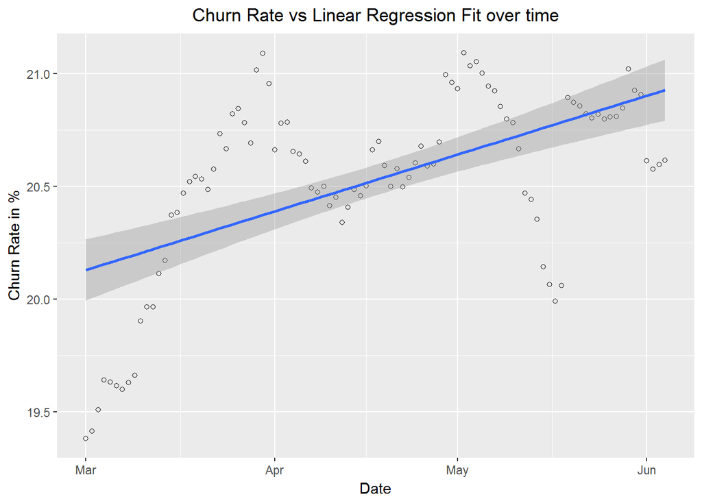

```r
library("ggplot2")
ggplot(tasks.ts[60:155,], aes(x=Date, y=ChurnRate)) + geom_point(shape=1) + geom_smooth(method=lm) +
  labs(title="Churn Rate vs Linear Regression Fit over time",y="Churn Rate in %")  + theme(plot.title = element_text(hjust = 0.5))
```

In the next plot, we look at the number of active users over time. In this plot, we definitely see a clear rise in active users over time!

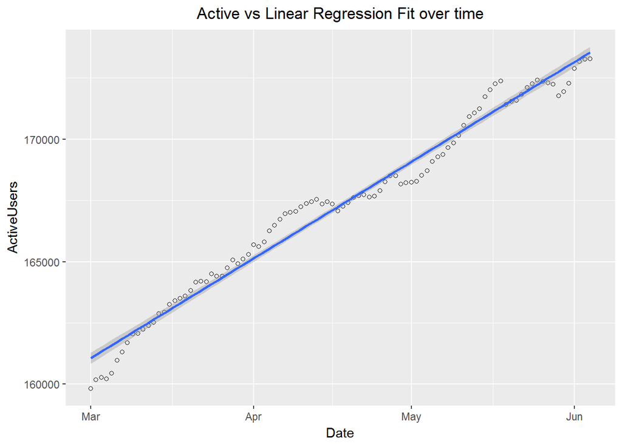

```r
ggplot(tasks.ts[60:155,], aes(x=Date, y=ActiveUsers)) + geom_point(shape=1) + geom_smooth(method=lm) +
  labs(title="Active vs Linear Regression Fit over time")  + theme(plot.title = element_text(hjust = 0.5))
```

## Step 4: Things I would like to do, given more data and time.

1. Use a better churn rate: https://blog.recurly.com/2014/08/better-way-to-calculate-your-churn-rate
2. Do some time series analysis, preferably with multiple years, since we really need a 60 day lead time for unbiased data, leaving us with only 3 months worth of unbiased data currently
3. Subset by user length - are users who have been active for a while less likely to churn compared to users that have only been active for a short time. Again, a longer series of data is needed for this.
4. Look at higher granality of time - weeks or months.
5. How does number of tasks/day affect churn?